# 02_string_animation

## 02_string_animation

#### Question

1. A taught string, fixed at 2 ends, produces a harmonic series based on the [standing waves](https://en.wikipedia.org/wiki/Standing_wave#Standing_wave_on_a_string_with_two_fixed_ends) that [resonate](https://en.wikipedia.org/wiki/Resonance). Other frequencies fizzle out quickly because they are not resonant with the system.

   We will simulate a string vibrating at its [fundamental frequency](https://en.wikipedia.org/wiki/Fundamental_frequency) and two of its [overtones](https://en.wikipedia.org/wiki/Overtone). We will also pay attention to the phase of each partial.

   Let’s assume the string is of length $\pi$ meters and the period of the fundamental is $2\pi$ seconds (so $t$ goes from 0 to $2\pi$).

   $$y_1 = A_1 \sin(x)\cdot \sin(t+\phi_1)$$

   where $A_1$ is the amplitude of the fundamental and $\phi_1$ is the phase of the fundamental.

   The next two overtones have similar equations.

   $$y_2 = A_2 \sin(2x)\cdot \sin(2t+\phi_2)$$

   $$y_3 = A_3 \sin(3x)\cdot \sin(3t+\phi_3)$$

   When all three modes of oscillation occur simultaneously, the result is a superposition of waves.

   $$y = y_1+y_2+y_3$$

   Determine which set of parameters generates the animation below (when viewing the superposition).

### Parameter set 1

   $$\begin{align*}
   A_1 &= 0.09 & \phi_1 &= 0.25 \\
   A_2 &= 0.11 & \phi_2 &= 3.18 \\
   A_3 &= 0.8 & \phi_3 &= 0.33 \\
   \end{align*}$$

### Parameter set 2

   $$\begin{align*}
   A_1 &= 0.47 & \phi_1 &= 5.27 \\
   A_2 &= 0.45 & \phi_2 &= 5.2 \\
   A_3 &= 0.08 & \phi_3 &= 5.45 \\
   \end{align*}$$

### Parameter set 3

   $$\begin{align*}
   A_1 &= 0.76 & \phi_1 &= 2.83 \\
   A_2 &= 0.07 & \phi_2 &= 4.82 \\
   A_3 &= 0.17 & \phi_3 &= 2.99 \\
   \end{align*}$$

### Parameter set 4

   $$\begin{align*}
   A_1 &= 0.11 & \phi_1 &= 2.53 \\
   A_2 &= 0.42 & \phi_2 &= 6.01 \\
   A_3 &= 0.47 & \phi_3 &= 2.04 \\
   \end{align*}$$

### Parameter set 5

   $$\begin{align*}
   A_1 &= 0.14 & \phi_1 &= 5.89 \\
   A_2 &= 0.76 & \phi_2 &= 0.07 \\
   A_3 &= 0.1 & \phi_3 &= 0.57 \\
   \end{align*}$$

### Parameter set 6

   $$\begin{align*}
   A_1 &= 0.41 & \phi_1 &= 2.41 \\
   A_2 &= 0.14 & \phi_2 &= 0.68 \\
   A_3 &= 0.45 & \phi_3 &= 4.03 \\
   \end{align*}$$

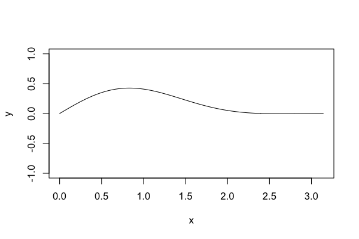

   1. Parameter set 1
   2. Parameter set 2
   3. Parameter set 3
   4. Parameter set 4
   5. Parameter set 5
   6. Parameter set 6

#### Question

2. A taught string, fixed at 2 ends, produces a harmonic series based on the [standing waves](https://en.wikipedia.org/wiki/Standing_wave#Standing_wave_on_a_string_with_two_fixed_ends) that [resonate](https://en.wikipedia.org/wiki/Resonance). Other frequencies fizzle out quickly because they are not resonant with the system.

   We will simulate a string vibrating at its [fundamental frequency](https://en.wikipedia.org/wiki/Fundamental_frequency) and two of its [overtones](https://en.wikipedia.org/wiki/Overtone). We will also pay attention to the phase of each partial.

   Let’s assume the string is of length $\pi$ meters and the period of the fundamental is $2\pi$ seconds (so $t$ goes from 0 to $2\pi$).

   $$y_1 = A_1 \sin(x)\cdot \sin(t+\phi_1)$$

   where $A_1$ is the amplitude of the fundamental and $\phi_1$ is the phase of the fundamental.

   The next two overtones have similar equations.

   $$y_2 = A_2 \sin(2x)\cdot \sin(2t+\phi_2)$$

   $$y_3 = A_3 \sin(3x)\cdot \sin(3t+\phi_3)$$

   When all three modes of oscillation occur simultaneously, the result is a superposition of waves.

   $$y = y_1+y_2+y_3$$

   Determine which set of parameters generates the animation below (when viewing the superposition).

### Parameter set 1

   $$\begin{align*}
   A_1 &= 0.43 & \phi_1 &= 4.4 \\
   A_2 &= 0.45 & \phi_2 &= 4.02 \\
   A_3 &= 0.12 & \phi_3 &= 5.37 \\
   \end{align*}$$

### Parameter set 2

   $$\begin{align*}
   A_1 &= 0.83 & \phi_1 &= 4.61 \\
   A_2 &= 0.08 & \phi_2 &= 1.22 \\
   A_3 &= 0.09 & \phi_3 &= 1.76 \\
   \end{align*}$$

### Parameter set 3

   $$\begin{align*}
   A_1 &= 0.14 & \phi_1 &= 4.61 \\
   A_2 &= 0.11 & \phi_2 &= 2.45 \\
   A_3 &= 0.75 & \phi_3 &= 4.94 \\
   \end{align*}$$

### Parameter set 4

   $$\begin{align*}
   A_1 &= 0.09 & \phi_1 &= 1.56 \\
   A_2 &= 0.83 & \phi_2 &= 4.25 \\
   A_3 &= 0.08 & \phi_3 &= 5.21 \\
   \end{align*}$$

### Parameter set 5

   $$\begin{align*}
   A_1 &= 0.1 & \phi_1 &= 5.92 \\
   A_2 &= 0.48 & \phi_2 &= 2.99 \\
   A_3 &= 0.42 & \phi_3 &= 1.25 \\
   \end{align*}$$

### Parameter set 6

   $$\begin{align*}
   A_1 &= 0.49 & \phi_1 &= 3.25 \\
   A_2 &= 0.13 & \phi_2 &= 1.83 \\
   A_3 &= 0.38 & \phi_3 &= 1.17 \\
   \end{align*}$$

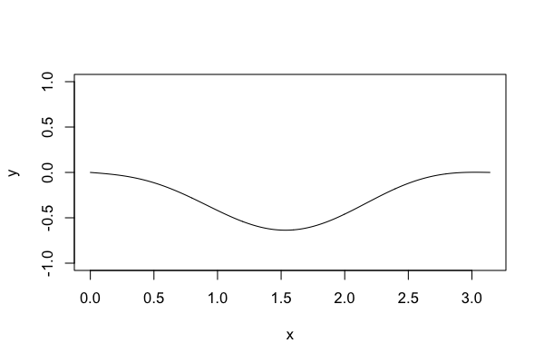

   1. Parameter set 1
   2. Parameter set 2
   3. Parameter set 3
   4. Parameter set 4
   5. Parameter set 5
   6. Parameter set 6

#### Question

3. A taught string, fixed at 2 ends, produces a harmonic series based on the [standing waves](https://en.wikipedia.org/wiki/Standing_wave#Standing_wave_on_a_string_with_two_fixed_ends) that [resonate](https://en.wikipedia.org/wiki/Resonance). Other frequencies fizzle out quickly because they are not resonant with the system.

   We will simulate a string vibrating at its [fundamental frequency](https://en.wikipedia.org/wiki/Fundamental_frequency) and two of its [overtones](https://en.wikipedia.org/wiki/Overtone). We will also pay attention to the phase of each partial.

   Let’s assume the string is of length $\pi$ meters and the period of the fundamental is $2\pi$ seconds (so $t$ goes from 0 to $2\pi$).

   $$y_1 = A_1 \sin(x)\cdot \sin(t+\phi_1)$$

   where $A_1$ is the amplitude of the fundamental and $\phi_1$ is the phase of the fundamental.

   The next two overtones have similar equations.

   $$y_2 = A_2 \sin(2x)\cdot \sin(2t+\phi_2)$$

   $$y_3 = A_3 \sin(3x)\cdot \sin(3t+\phi_3)$$

   When all three modes of oscillation occur simultaneously, the result is a superposition of waves.

   $$y = y_1+y_2+y_3$$

   Determine which set of parameters generates the animation below (when viewing the superposition).

### Parameter set 1

   $$\begin{align*}
   A_1 &= 0.83 & \phi_1 &= 3.02 \\
   A_2 &= 0.07 & \phi_2 &= 2.37 \\
   A_3 &= 0.1 & \phi_3 &= 2.58 \\
   \end{align*}$$

### Parameter set 2

   $$\begin{align*}
   A_1 &= 0.07 & \phi_1 &= 5.6 \\
   A_2 &= 0.84 & \phi_2 &= 1.01 \\
   A_3 &= 0.09 & \phi_3 &= 4.84 \\
   \end{align*}$$

### Parameter set 3

   $$\begin{align*}
   A_1 &= 0.42 & \phi_1 &= 3.07 \\
   A_2 &= 0.06 & \phi_2 &= 2.08 \\
   A_3 &= 0.52 & \phi_3 &= 2.53 \\
   \end{align*}$$

### Parameter set 4

   $$\begin{align*}
   A_1 &= 0.12 & \phi_1 &= 5.73 \\
   A_2 &= 0.08 & \phi_2 &= 0.14 \\
   A_3 &= 0.8 & \phi_3 &= 3.4 \\
   \end{align*}$$

### Parameter set 5

   $$\begin{align*}
   A_1 &= 0.42 & \phi_1 &= 6.28 \\
   A_2 &= 0.49 & \phi_2 &= 4.29 \\
   A_3 &= 0.09 & \phi_3 &= 0.5 \\
   \end{align*}$$

### Parameter set 6

   $$\begin{align*}
   A_1 &= 0.13 & \phi_1 &= 4.6 \\
   A_2 &= 0.43 & \phi_2 &= 2.66 \\
   A_3 &= 0.44 & \phi_3 &= 1.26 \\
   \end{align*}$$

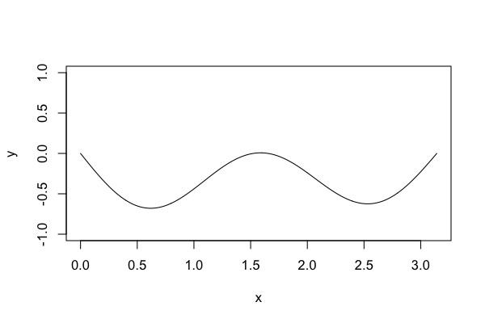

   1. Parameter set 1
   2. Parameter set 2
   3. Parameter set 3
   4. Parameter set 4
   5. Parameter set 5
   6. Parameter set 6

#### Question

4. A taught string, fixed at 2 ends, produces a harmonic series based on the [standing waves](https://en.wikipedia.org/wiki/Standing_wave#Standing_wave_on_a_string_with_two_fixed_ends) that [resonate](https://en.wikipedia.org/wiki/Resonance). Other frequencies fizzle out quickly because they are not resonant with the system.

   We will simulate a string vibrating at its [fundamental frequency](https://en.wikipedia.org/wiki/Fundamental_frequency) and two of its [overtones](https://en.wikipedia.org/wiki/Overtone). We will also pay attention to the phase of each partial.

   Let’s assume the string is of length $\pi$ meters and the period of the fundamental is $2\pi$ seconds (so $t$ goes from 0 to $2\pi$).

   $$y_1 = A_1 \sin(x)\cdot \sin(t+\phi_1)$$

   where $A_1$ is the amplitude of the fundamental and $\phi_1$ is the phase of the fundamental.

   The next two overtones have similar equations.

   $$y_2 = A_2 \sin(2x)\cdot \sin(2t+\phi_2)$$

   $$y_3 = A_3 \sin(3x)\cdot \sin(3t+\phi_3)$$

   When all three modes of oscillation occur simultaneously, the result is a superposition of waves.

   $$y = y_1+y_2+y_3$$

   Determine which set of parameters generates the animation below (when viewing the superposition).

### Parameter set 1

   $$\begin{align*}
   A_1 &= 0.1 & \phi_1 &= 2.35 \\
   A_2 &= 0.48 & \phi_2 &= 1.55 \\
   A_3 &= 0.42 & \phi_3 &= 1.69 \\
   \end{align*}$$

### Parameter set 2

   $$\begin{align*}
   A_1 &= 0.11 & \phi_1 &= 6.16 \\
   A_2 &= 0.14 & \phi_2 &= 6.14 \\
   A_3 &= 0.75 & \phi_3 &= 3.83 \\
   \end{align*}$$

### Parameter set 3

   $$\begin{align*}
   A_1 &= 0.14 & \phi_1 &= 4.51 \\
   A_2 &= 0.83 & \phi_2 &= 2.1 \\
   A_3 &= 0.03 & \phi_3 &= 4.91 \\
   \end{align*}$$

### Parameter set 4

   $$\begin{align*}
   A_1 &= 0.49 & \phi_1 &= 0.4 \\
   A_2 &= 0.12 & \phi_2 &= 4.11 \\
   A_3 &= 0.39 & \phi_3 &= 2.94 \\
   \end{align*}$$

### Parameter set 5

   $$\begin{align*}
   A_1 &= 0.82 & \phi_1 &= 6.1 \\
   A_2 &= 0.14 & \phi_2 &= 4.47 \\
   A_3 &= 0.04 & \phi_3 &= 6.19 \\
   \end{align*}$$

### Parameter set 6

   $$\begin{align*}
   A_1 &= 0.42 & \phi_1 &= 0.39 \\
   A_2 &= 0.47 & \phi_2 &= 1.76 \\
   A_3 &= 0.11 & \phi_3 &= 2.58 \\
   \end{align*}$$

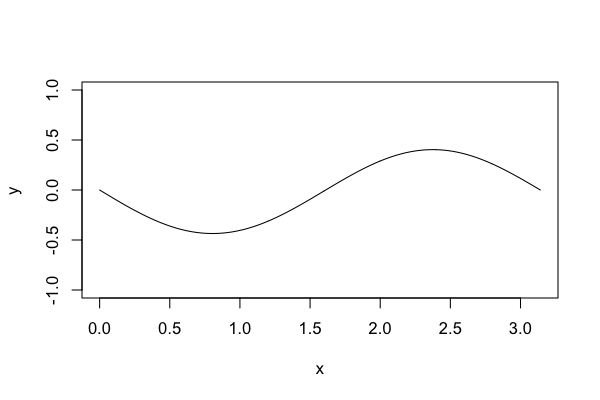

   1. Parameter set 1
   2. Parameter set 2
   3. Parameter set 3
   4. Parameter set 4
   5. Parameter set 5
   6. Parameter set 6

#### Question

5. A taught string, fixed at 2 ends, produces a harmonic series based on the [standing waves](https://en.wikipedia.org/wiki/Standing_wave#Standing_wave_on_a_string_with_two_fixed_ends) that [resonate](https://en.wikipedia.org/wiki/Resonance). Other frequencies fizzle out quickly because they are not resonant with the system.

   We will simulate a string vibrating at its [fundamental frequency](https://en.wikipedia.org/wiki/Fundamental_frequency) and two of its [overtones](https://en.wikipedia.org/wiki/Overtone). We will also pay attention to the phase of each partial.

   Let’s assume the string is of length $\pi$ meters and the period of the fundamental is $2\pi$ seconds (so $t$ goes from 0 to $2\pi$).

   $$y_1 = A_1 \sin(x)\cdot \sin(t+\phi_1)$$

   where $A_1$ is the amplitude of the fundamental and $\phi_1$ is the phase of the fundamental.

   The next two overtones have similar equations.

   $$y_2 = A_2 \sin(2x)\cdot \sin(2t+\phi_2)$$

   $$y_3 = A_3 \sin(3x)\cdot \sin(3t+\phi_3)$$

   When all three modes of oscillation occur simultaneously, the result is a superposition of waves.

   $$y = y_1+y_2+y_3$$

   Determine which set of parameters generates the animation below (when viewing the superposition).

### Parameter set 1

   $$\begin{align*}
   A_1 &= 0.44 & \phi_1 &= 1.49 \\
   A_2 &= 0.43 & \phi_2 &= 2.63 \\
   A_3 &= 0.13 & \phi_3 &= 0.4 \\
   \end{align*}$$

### Parameter set 2

   $$\begin{align*}
   A_1 &= 0.1 & \phi_1 &= 5.65 \\
   A_2 &= 0.13 & \phi_2 &= 3.43 \\
   A_3 &= 0.77 & \phi_3 &= 5.13 \\
   \end{align*}$$

### Parameter set 3

   $$\begin{align*}
   A_1 &= 0.13 & \phi_1 &= 1.63 \\
   A_2 &= 0.42 & \phi_2 &= 3.16 \\
   A_3 &= 0.45 & \phi_3 &= 0.43 \\
   \end{align*}$$

### Parameter set 4

   $$\begin{align*}
   A_1 &= 0.77 & \phi_1 &= 0.21 \\
   A_2 &= 0.08 & \phi_2 &= 2 \\
   A_3 &= 0.15 & \phi_3 &= 0.14 \\
   \end{align*}$$

### Parameter set 5

   $$\begin{align*}
   A_1 &= 0.43 & \phi_1 &= 5.2 \\
   A_2 &= 0.09 & \phi_2 &= 1.9 \\
   A_3 &= 0.48 & \phi_3 &= 3.3 \\
   \end{align*}$$

### Parameter set 6

   $$\begin{align*}
   A_1 &= 0.06 & \phi_1 &= 0.24 \\
   A_2 &= 0.78 & \phi_2 &= 0.88 \\
   A_3 &= 0.16 & \phi_3 &= 5.94 \\
   \end{align*}$$

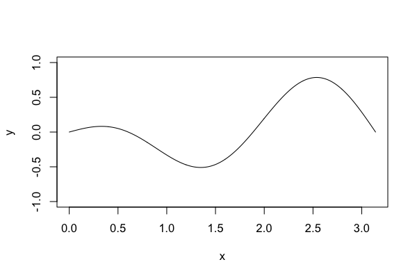

   1. Parameter set 1
   2. Parameter set 2
   3. Parameter set 3
   4. Parameter set 4
   5. Parameter set 5
   6. Parameter set 6

#### Question

6. A taught string, fixed at 2 ends, produces a harmonic series based on the [standing waves](https://en.wikipedia.org/wiki/Standing_wave#Standing_wave_on_a_string_with_two_fixed_ends) that [resonate](https://en.wikipedia.org/wiki/Resonance). Other frequencies fizzle out quickly because they are not resonant with the system.

   We will simulate a string vibrating at its [fundamental frequency](https://en.wikipedia.org/wiki/Fundamental_frequency) and two of its [overtones](https://en.wikipedia.org/wiki/Overtone). We will also pay attention to the phase of each partial.

   Let’s assume the string is of length $\pi$ meters and the period of the fundamental is $2\pi$ seconds (so $t$ goes from 0 to $2\pi$).

   $$y_1 = A_1 \sin(x)\cdot \sin(t+\phi_1)$$

   where $A_1$ is the amplitude of the fundamental and $\phi_1$ is the phase of the fundamental.

   The next two overtones have similar equations.

   $$y_2 = A_2 \sin(2x)\cdot \sin(2t+\phi_2)$$

   $$y_3 = A_3 \sin(3x)\cdot \sin(3t+\phi_3)$$

   When all three modes of oscillation occur simultaneously, the result is a superposition of waves.

   $$y = y_1+y_2+y_3$$

   Determine which set of parameters generates the animation below (when viewing the superposition).

### Parameter set 1

   $$\begin{align*}
   A_1 &= 0.84 & \phi_1 &= 0.27 \\
   A_2 &= 0.06 & \phi_2 &= 3.77 \\
   A_3 &= 0.1 & \phi_3 &= 1.74 \\
   \end{align*}$$

### Parameter set 2

   $$\begin{align*}
   A_1 &= 0.08 & \phi_1 &= 0.29 \\
   A_2 &= 0.49 & \phi_2 &= 0.33 \\
   A_3 &= 0.43 & \phi_3 &= 5.18 \\
   \end{align*}$$

### Parameter set 3

   $$\begin{align*}
   A_1 &= 0.44 & \phi_1 &= 3.14 \\
   A_2 &= 0.49 & \phi_2 &= 4.92 \\
   A_3 &= 0.07 & \phi_3 &= 2.16 \\
   \end{align*}$$

### Parameter set 4

   $$\begin{align*}
   A_1 &= 0.44 & \phi_1 &= 1.7 \\
   A_2 &= 0.06 & \phi_2 &= 5.86 \\
   A_3 &= 0.5 & \phi_3 &= 4.15 \\
   \end{align*}$$

### Parameter set 5

   $$\begin{align*}
   A_1 &= 0.07 & \phi_1 &= 3.92 \\
   A_2 &= 0.78 & \phi_2 &= 5.88 \\
   A_3 &= 0.15 & \phi_3 &= 4.77 \\
   \end{align*}$$

### Parameter set 6

   $$\begin{align*}
   A_1 &= 0.14 & \phi_1 &= 0.72 \\
   A_2 &= 0.11 & \phi_2 &= 5.82 \\
   A_3 &= 0.75 & \phi_3 &= 5.99 \\
   \end{align*}$$

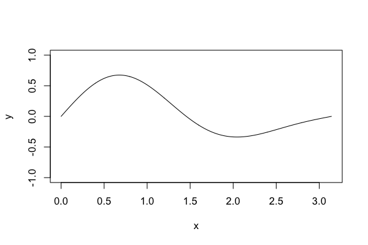

   1. Parameter set 1
   2. Parameter set 2
   3. Parameter set 3
   4. Parameter set 4
   5. Parameter set 5
   6. Parameter set 6

#### Question

7. A taught string, fixed at 2 ends, produces a harmonic series based on the [standing waves](https://en.wikipedia.org/wiki/Standing_wave#Standing_wave_on_a_string_with_two_fixed_ends) that [resonate](https://en.wikipedia.org/wiki/Resonance). Other frequencies fizzle out quickly because they are not resonant with the system.

   We will simulate a string vibrating at its [fundamental frequency](https://en.wikipedia.org/wiki/Fundamental_frequency) and two of its [overtones](https://en.wikipedia.org/wiki/Overtone). We will also pay attention to the phase of each partial.

   Let’s assume the string is of length $\pi$ meters and the period of the fundamental is $2\pi$ seconds (so $t$ goes from 0 to $2\pi$).

   $$y_1 = A_1 \sin(x)\cdot \sin(t+\phi_1)$$

   where $A_1$ is the amplitude of the fundamental and $\phi_1$ is the phase of the fundamental.

   The next two overtones have similar equations.

   $$y_2 = A_2 \sin(2x)\cdot \sin(2t+\phi_2)$$

   $$y_3 = A_3 \sin(3x)\cdot \sin(3t+\phi_3)$$

   When all three modes of oscillation occur simultaneously, the result is a superposition of waves.

   $$y = y_1+y_2+y_3$$

   Determine which set of parameters generates the animation below (when viewing the superposition).

### Parameter set 1

   $$\begin{align*}
   A_1 &= 0.13 & \phi_1 &= 2.98 \\
   A_2 &= 0.43 & \phi_2 &= 3.41 \\
   A_3 &= 0.44 & \phi_3 &= 2.57 \\
   \end{align*}$$

### Parameter set 2

   $$\begin{align*}
   A_1 &= 0.11 & \phi_1 &= 2.64 \\
   A_2 &= 0.07 & \phi_2 &= 5.42 \\
   A_3 &= 0.82 & \phi_3 &= 1.19 \\
   \end{align*}$$

### Parameter set 3

   $$\begin{align*}
   A_1 &= 0.11 & \phi_1 &= 1.59 \\
   A_2 &= 0.83 & \phi_2 &= 4.37 \\
   A_3 &= 0.06 & \phi_3 &= 2.09 \\
   \end{align*}$$

### Parameter set 4

   $$\begin{align*}
   A_1 &= 0.76 & \phi_1 &= 6.27 \\
   A_2 &= 0.11 & \phi_2 &= 1.99 \\
   A_3 &= 0.13 & \phi_3 &= 2.9 \\
   \end{align*}$$

### Parameter set 5

   $$\begin{align*}
   A_1 &= 0.44 & \phi_1 &= 4.25 \\
   A_2 &= 0.11 & \phi_2 &= 2.4 \\
   A_3 &= 0.45 & \phi_3 &= 4.74 \\
   \end{align*}$$

### Parameter set 6

   $$\begin{align*}
   A_1 &= 0.41 & \phi_1 &= 5.42 \\
   A_2 &= 0.45 & \phi_2 &= 4.66 \\
   A_3 &= 0.14 & \phi_3 &= 0.93 \\
   \end{align*}$$

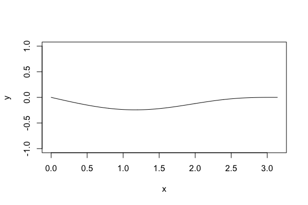

   1. Parameter set 1
   2. Parameter set 2
   3. Parameter set 3
   4. Parameter set 4
   5. Parameter set 5
   6. Parameter set 6

#### Question

8. A taught string, fixed at 2 ends, produces a harmonic series based on the [standing waves](https://en.wikipedia.org/wiki/Standing_wave#Standing_wave_on_a_string_with_two_fixed_ends) that [resonate](https://en.wikipedia.org/wiki/Resonance). Other frequencies fizzle out quickly because they are not resonant with the system.

   We will simulate a string vibrating at its [fundamental frequency](https://en.wikipedia.org/wiki/Fundamental_frequency) and two of its [overtones](https://en.wikipedia.org/wiki/Overtone). We will also pay attention to the phase of each partial.

   Let’s assume the string is of length $\pi$ meters and the period of the fundamental is $2\pi$ seconds (so $t$ goes from 0 to $2\pi$).

   $$y_1 = A_1 \sin(x)\cdot \sin(t+\phi_1)$$

   where $A_1$ is the amplitude of the fundamental and $\phi_1$ is the phase of the fundamental.

   The next two overtones have similar equations.

   $$y_2 = A_2 \sin(2x)\cdot \sin(2t+\phi_2)$$

   $$y_3 = A_3 \sin(3x)\cdot \sin(3t+\phi_3)$$

   When all three modes of oscillation occur simultaneously, the result is a superposition of waves.

   $$y = y_1+y_2+y_3$$

   Determine which set of parameters generates the animation below (when viewing the superposition).

### Parameter set 1

   $$\begin{align*}
   A_1 &= 0.42 & \phi_1 &= 0.05 \\
   A_2 &= 0.41 & \phi_2 &= 2.96 \\
   A_3 &= 0.17 & \phi_3 &= 0.63 \\
   \end{align*}$$

### Parameter set 2

   $$\begin{align*}
   A_1 &= 0.84 & \phi_1 &= 0.44 \\
   A_2 &= 0.12 & \phi_2 &= 1.24 \\
   A_3 &= 0.04 & \phi_3 &= 0.17 \\
   \end{align*}$$

### Parameter set 3

   $$\begin{align*}
   A_1 &= 0.49 & \phi_1 &= 5.52 \\
   A_2 &= 0.11 & \phi_2 &= 5.7 \\
   A_3 &= 0.4 & \phi_3 &= 1.37 \\
   \end{align*}$$

### Parameter set 4

   $$\begin{align*}
   A_1 &= 0.13 & \phi_1 &= 3.4 \\
   A_2 &= 0.46 & \phi_2 &= 1.51 \\
   A_3 &= 0.41 & \phi_3 &= 5.01 \\
   \end{align*}$$

### Parameter set 5

   $$\begin{align*}
   A_1 &= 0.11 & \phi_1 &= 0.47 \\
   A_2 &= 0.76 & \phi_2 &= 0.19 \\
   A_3 &= 0.13 & \phi_3 &= 2.51 \\
   \end{align*}$$

### Parameter set 6

   $$\begin{align*}
   A_1 &= 0.09 & \phi_1 &= 6.12 \\
   A_2 &= 0.07 & \phi_2 &= 5.55 \\
   A_3 &= 0.84 & \phi_3 &= 0.02 \\
   \end{align*}$$

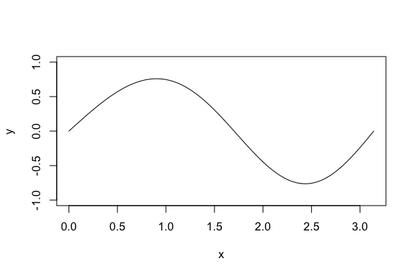

   1. Parameter set 1
   2. Parameter set 2
   3. Parameter set 3
   4. Parameter set 4
   5. Parameter set 5
   6. Parameter set 6